# 02. 板情報を使った極短期価格予測シグナルの分析

## 目的

bitbankの板の動きが極短期の価格変動に与える影響を分析し、MM戦略で使えるシグナルを発見する。

## 分析内容

1. Order Imbalance（板の偏り）と価格変動の関係
2. 板の変化速度と価格変動の関係
3. 約定フロー（買い/売りの連続性）と価格変動
4. 予測シグナルの有効性検証

```python
# 基本セットアップ
from etr.auto_import import *
HTML(full_width_display)
```

```python
# 追加ライブラリ
from etr.data.data_loader import load_data
import warnings
warnings.filterwarnings('ignore')
```

## 1. データ読み込み

XRPJPYのMarketBookとMarketTradeデータを1日分読み込む。

```python
# パラメータ設定
venue = 'bitbank'
sym = 'XRPJPY'  # 最も約定が多いペア
sample_date = '2026-01-25'

print(f"対象: {venue} {sym}")
print(f"日付: {sample_date}")
```

```
対象: bitbank XRPJPY
日付: 2026-01-25
```

```python
# MarketBookデータの読み込み
book_df = load_data(sample_date, 'MarketBook', venue, sym)
print(f"MarketBook: {len(book_df)} rows")
display(book_df.head(2))
```

```
2026-02-01 13:31:04.543|INFO    |etr.data.data_loader: data_loader.load_data 95|Found 1 HDB files, process loading...
```

```
MarketBook: 244469 rows
```

|  | timestamp | market_created_timestamp | sym | venue | category | bids | asks | universal_id | misc |
| --- | --- | --- | --- | --- | --- | --- | --- | --- | --- |
| 0 | 2026-01-25 00:00:00.075624+00:00 | 2026-01-25 00:00:00.074000+00:00 | XRPJPY | bitbank | None | [[298.615, 107.6762], [298.586, 0.014], [298.5... | [[298.616, 175557.6908], [298.621, 200.0], [29... | 219cca6fa7684118af5b3a0b8344d214 | ['diff', 30209808706] |
| 1 | 2026-01-25 00:00:00.401787+00:00 | 2026-01-25 00:00:00.404000+00:00 | XRPJPY | bitbank | None | [[298.615, 107.6762], [298.586, 0.014], [298.5... | [[298.616, 175557.6908], [298.618, 200.0], [29... | 9349897fb0b5420fb59fb220be2a5d78 | ['diff', 30209808718] |

```python
# MarketTradeデータの読み込み
trade_df = load_data(sample_date, 'MarketTrade', venue, sym)
print(f"MarketTrade: {len(trade_df)} rows")
display(trade_df.head(2))
```

```
2026-02-01 13:31:06.330|INFO    |etr.data.data_loader: data_loader.load_data 95|Found 1 HDB files, process loading...
```

```
MarketTrade: 20516 rows
```

|  | timestamp | market_created_timestamp | sym | venue | category | side | price | amount | trade_id | order_ids | misc | universal_id |
| --- | --- | --- | --- | --- | --- | --- | --- | --- | --- | --- | --- | --- |
| 0 | 2026-01-25 00:00:04.771428+00:00 | 2026-01-25 00:00:04.557000+00:00 | XRPJPY | bitbank | None | -1 | 298.615 | 5.276 | 1223080841 | None | None | e834be93af344b179091ca2e3035d03a |
| 1 | 2026-01-25 00:00:04.771623+00:00 | 2026-01-25 00:00:04.557000+00:00 | XRPJPY | bitbank | None | -1 | 298.615 | 0.494 | 1223080842 | None | None | 686ce71e5b3e4b999c3dada149c3e8da |

## 2. Order Imbalance（板の偏り）の計算

板の買い/売りの偏りを計算。これが価格変動の先行指標になるか検証。

```python
# 板情報から特徴量を抽出
def extract_book_features(row, n_levels=5):
    """板情報から特徴量を抽出"""
    bids = row['bids']
    asks = row['asks']

    # Best prices
    best_bid = bids[0][0] if len(bids) > 0 else np.nan
    best_ask = asks[0][0] if len(asks) > 0 else np.nan
    mid_price = (best_bid + best_ask) / 2
    spread = best_ask - best_bid

    # Volume at each level
    bid_volumes = [bids[i][1] if i < len(bids) else 0 for i in range(n_levels)]
    ask_volumes = [asks[i][1] if i < len(asks) else 0 for i in range(n_levels)]

    # Total volume
    total_bid_vol = sum(bid_volumes)
    total_ask_vol = sum(ask_volumes)

    # Order Imbalance
    imbalance = (total_bid_vol - total_ask_vol) / (total_bid_vol + total_ask_vol) if (total_bid_vol + total_ask_vol) > 0 else 0

    # Level 1 imbalance
    l1_bid = bid_volumes[0]
    l1_ask = ask_volumes[0]
    l1_imbalance = (l1_bid - l1_ask) / (l1_bid + l1_ask) if (l1_bid + l1_ask) > 0 else 0

    return {
        'best_bid': best_bid,
        'best_ask': best_ask,
        'mid_price': mid_price,
        'spread': spread,
        'bid_vol_total': total_bid_vol,
        'ask_vol_total': total_ask_vol,
        'imbalance': imbalance,
        'l1_imbalance': l1_imbalance,
        'l1_bid_vol': l1_bid,
        'l1_ask_vol': l1_ask
    }

# 特徴量抽出
features = []
for idx, row in book_df.iterrows():
    feat = extract_book_features(row)
    feat['timestamp'] = row['timestamp']
    features.append(feat)

feat_df = pd.DataFrame(features)
feat_df = feat_df.set_index('timestamp')
print(f"特徴量抽出完了: {len(feat_df)} rows")
display(feat_df.head())
```

```
特徴量抽出完了: 244469 rows
```

| timestamp | best_bid | best_ask | mid_price | spread | bid_vol_total | ask_vol_total | imbalance | l1_imbalance | l1_bid_vol | l1_ask_vol |
| --- | --- | --- | --- | --- | --- | --- | --- | --- | --- | --- |
| 2026-01-25 00:00:00.075624+00:00 | 298.615 | 298.616 | 298.6155 | 0.001 | 508.6902 | 176242.9811 | -0.994244 | -0.998774 | 107.6762 | 175557.6908 |
| 2026-01-25 00:00:00.401787+00:00 | 298.615 | 298.616 | 298.6155 | 0.001 | 508.6902 | 176242.9811 | -0.994244 | -0.998774 | 107.6762 | 175557.6908 |
| 2026-01-25 00:00:00.773495+00:00 | 298.615 | 298.616 | 298.6155 | 0.001 | 708.6770 | 176242.9811 | -0.991990 | -0.996501 | 307.6630 | 175557.6908 |
| 2026-01-25 00:00:01.105807+00:00 | 298.615 | 298.616 | 298.6155 | 0.001 | 775.9372 | 176807.6908 | -0.991261 | -0.996501 | 307.6630 | 175557.6908 |
| 2026-01-25 00:00:01.607923+00:00 | 298.615 | 298.616 | 298.6155 | 0.001 | 1375.9372 | 176807.6908 | -0.984556 | -0.996501 | 307.6630 | 175557.6908 |

```python
# 将来の価格変動を計算（予測対象）
# 100ms, 500ms, 1s, 5s後の価格変動をbpsで計算

horizons = {
    '100ms': pd.Timedelta(milliseconds=100),
    '500ms': pd.Timedelta(milliseconds=500),
    '1s': pd.Timedelta(seconds=1),
    '5s': pd.Timedelta(seconds=5),
    '10s': pd.Timedelta(seconds=10)
}

for name, delta in horizons.items():
    # 将来のmid_priceを取得
    future_idx = feat_df.index + delta
    future_prices = feat_df['mid_price'].reindex(future_idx, method='ffill')
    future_prices.index = feat_df.index

    # 価格変動をbpsで計算
    feat_df[f'return_{name}_bps'] = (future_prices.values - feat_df['mid_price'].values) / feat_df['mid_price'].values * 10000

print("将来リターン計算完了")
display(feat_df[['mid_price'] + [f'return_{k}_bps' for k in horizons.keys()]].describe().round(2))
```

```
将来リターン計算完了
```

|  | mid_price | return_100ms_bps | return_500ms_bps | return_1s_bps | return_5s_bps | return_10s_bps |
| --- | --- | --- | --- | --- | --- | --- |
| count | 244469.00 | 244469.00 | 244469.00 | 244469.00 | 244469.00 | 244469.00 |
| mean | 292.61 | 0.00 | -0.00 | -0.00 | -0.03 | -0.06 |
| std | 5.29 | 0.03 | 0.33 | 0.49 | 1.57 | 2.33 |
| min | 281.05 | -9.60 | -21.94 | -21.94 | -48.63 | -59.33 |
| 25% | 287.00 | 0.00 | 0.00 | 0.00 | 0.00 | 0.00 |
| 50% | 295.68 | 0.00 | 0.00 | 0.00 | 0.00 | 0.00 |
| 75% | 296.36 | 0.00 | 0.00 | 0.00 | 0.00 | 0.00 |
| max | 298.80 | 6.69 | 15.24 | 18.01 | 33.24 | 27.52 |

## 3. Order Imbalanceと価格変動の相関分析

```python
# Imbalanceと将来リターンの相関
corr_cols = ['imbalance', 'l1_imbalance'] + [f'return_{k}_bps' for k in horizons.keys()]
corr_matrix = feat_df[corr_cols].corr()

print("Imbalance vs 将来リターンの相関")
display(corr_matrix[['imbalance', 'l1_imbalance']].loc[[f'return_{k}_bps' for k in horizons.keys()]].round(4))
```

```
Imbalance vs 将来リターンの相関
```

|  | imbalance | l1_imbalance |
| --- | --- | --- |
| return_100ms_bps | 0.0060 | 0.0072 |
| return_500ms_bps | 0.0705 | 0.0840 |
| return_1s_bps | 0.0948 | 0.1131 |
| return_5s_bps | 0.1566 | 0.1877 |
| return_10s_bps | 0.1763 | 0.2114 |

```python
# Imbalanceを分位数で分けて、各グループの平均リターンを確認
feat_df['imbalance_quintile'] = pd.qcut(feat_df['imbalance'], q=5, labels=['Q1(Sell)', 'Q2', 'Q3', 'Q4', 'Q5(Buy)'])

quintile_returns = feat_df.groupby('imbalance_quintile')[[f'return_{k}_bps' for k in horizons.keys()]].mean()
print("Imbalance分位数別 平均将来リターン (bps)")
display(quintile_returns.round(3))
```

```
Imbalance分位数別 平均将来リターン (bps)
```

| imbalance_quintile | return_100ms_bps | return_500ms_bps | return_1s_bps | return_5s_bps | return_10s_bps |
| --- | --- | --- | --- | --- | --- |
| Q1(Sell) | -0.0 | -0.031 | -0.064 | -0.376 | -0.655 |
| Q2 | -0.0 | -0.020 | -0.040 | -0.187 | -0.321 |
| Q3 | 0.0 | -0.006 | -0.013 | -0.056 | -0.071 |
| Q4 | 0.0 | 0.017 | 0.036 | 0.161 | 0.230 |
| Q5(Buy) | 0.0 | 0.030 | 0.060 | 0.323 | 0.539 |

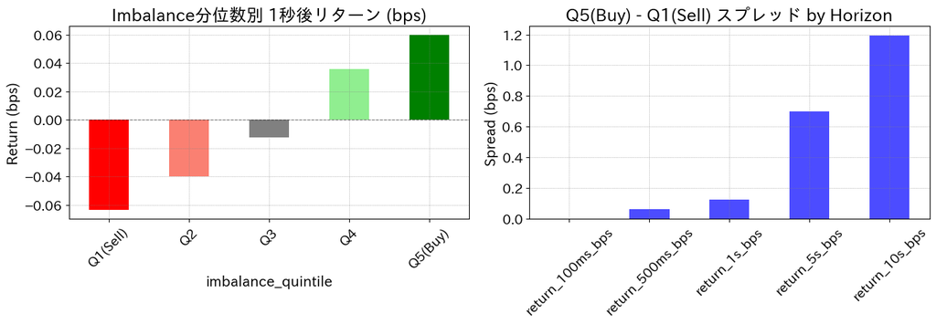

```python
# 可視化
fig, axes = plt.subplots(1, 2, figsize=(14, 5))

# Imbalance分位数別の1秒後リターン
quintile_returns['return_1s_bps'].plot(kind='bar', ax=axes[0], color=['red', 'salmon', 'gray', 'lightgreen', 'green'])
axes[0].set_title('Imbalance分位数別 1秒後リターン (bps)')
axes[0].set_ylabel('Return (bps)')
axes[0].axhline(y=0, color='black', linestyle='--', alpha=0.5)
axes[0].tick_params(axis='x', rotation=45)

# 各ホライズンでのQ5-Q1スプレッド
spreads = quintile_returns.loc['Q5(Buy)'] - quintile_returns.loc['Q1(Sell)']
spreads.plot(kind='bar', ax=axes[1], color='blue', alpha=0.7)
axes[1].set_title('Q5(Buy) - Q1(Sell) スプレッド by Horizon')
axes[1].set_ylabel('Spread (bps)')
axes[1].tick_params(axis='x', rotation=45)

plt.tight_layout()
plt.show()
```

## 4. 約定フローの分析

連続した買い/売り約定が価格変動を引き起こすか確認。

```python
# 約定データの前処理
trade_df['timestamp'] = pd.to_datetime(trade_df['timestamp'])
trade_df = trade_df.set_index('timestamp').sort_index()

# サイドの数値化
trade_df['side_num'] = trade_df['side'].map({'buy': 1, 'sell': -1})

# 1秒間の約定フローを集計
trade_1s = trade_df.resample('1s').agg({
    'amount': 'sum',
    'side_num': 'sum',  # 正:買い優勢、負:売り優勢
    'price': ['first', 'last', 'count']
})
trade_1s.columns = ['volume', 'net_flow', 'price_first', 'price_last', 'trade_count']
trade_1s['signed_volume'] = trade_df.groupby(pd.Grouper(freq='1s')).apply(
    lambda x: (x['amount'] * x['side_num']).sum()
)

print(f"1秒足データ: {len(trade_1s)} rows")
display(trade_1s.head())
```

```
1秒足データ: 86394 rows
```

| timestamp | volume | net_flow | price_first | price_last | trade_count | signed_volume |
| --- | --- | --- | --- | --- | --- | --- |
| 2026-01-25 00:00:04+00:00 | 307.6630 | 0.0 | 298.615 | 298.615 | 6 | 0.0 |
| 2026-01-25 00:00:05+00:00 | 0.0000 | 0.0 | NaN | NaN | 0 | 0.0 |
| 2026-01-25 00:00:06+00:00 | 0.0000 | 0.0 | NaN | NaN | 0 | 0.0 |
| 2026-01-25 00:00:07+00:00 | 3.1394 | 0.0 | 298.587 | 298.587 | 1 | 0.0 |
| 2026-01-25 00:00:08+00:00 | 0.0000 | 0.0 | NaN | NaN | 0 | 0.0 |

```python
# 約定フローと次の1秒の価格変動
trade_1s['next_return_bps'] = trade_1s['price_first'].shift(-1) / trade_1s['price_last'] * 10000 - 10000

# 約定フローを正規化
trade_1s['flow_norm'] = trade_1s['signed_volume'] / trade_1s['volume'].replace(0, np.nan)

# フローが大きいときの次のリターンを確認
trade_1s['flow_category'] = pd.cut(
    trade_1s['flow_norm'].fillna(0),
    bins=[-1.1, -0.5, -0.1, 0.1, 0.5, 1.1],
    labels=['Strong Sell', 'Weak Sell', 'Neutral', 'Weak Buy', 'Strong Buy']
)

flow_returns = trade_1s.groupby('flow_category')['next_return_bps'].agg(['mean', 'std', 'count'])
print("約定フロー別 次の1秒リターン")
display(flow_returns.round(3))
```

```
約定フロー別 次の1秒リターン
```

| flow_category | mean | std | count |
| --- | --- | --- | --- |
| Strong Sell | NaN | NaN | 0 |
| Weak Sell | NaN | NaN | 0 |
| Neutral | -0.016 | 1.453 | 1606 |
| Weak Buy | NaN | NaN | 0 |
| Strong Buy | NaN | NaN | 0 |

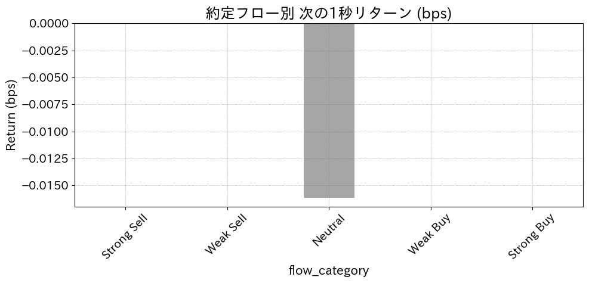

```python
# 可視化
fig, ax = plt.subplots(figsize=(10, 5))

flow_returns['mean'].plot(kind='bar', ax=ax, color=['red', 'salmon', 'gray', 'lightgreen', 'green'], alpha=0.7)
ax.set_title('約定フロー別 次の1秒リターン (bps)')
ax.set_ylabel('Return (bps)')
ax.axhline(y=0, color='black', linestyle='--', alpha=0.5)
ax.tick_params(axis='x', rotation=45)

plt.tight_layout()
plt.show()
```

## 5. 板の変化速度の分析

板が急激に変化するときに価格も動くか確認。

```python
# 板の変化量を計算
feat_df['imbalance_change'] = feat_df['imbalance'].diff()
feat_df['l1_bid_vol_change'] = feat_df['l1_bid_vol'].diff()
feat_df['l1_ask_vol_change'] = feat_df['l1_ask_vol'].diff()

# 板の変化と将来リターンの相関
change_cols = ['imbalance_change', 'l1_bid_vol_change', 'l1_ask_vol_change']
return_cols = [f'return_{k}_bps' for k in horizons.keys()]

change_corr = feat_df[change_cols + return_cols].corr()
print("板の変化と将来リターンの相関")
display(change_corr[change_cols].loc[return_cols].round(4))
```

```
板の変化と将来リターンの相関
```

|  | imbalance_change | l1_bid_vol_change | l1_ask_vol_change |
| --- | --- | --- | --- |
| return_100ms_bps | 0.0005 | 0.0005 | -0.0002 |
| return_500ms_bps | 0.0140 | -0.0014 | 0.0089 |
| return_1s_bps | 0.0155 | -0.0057 | 0.0091 |
| return_5s_bps | 0.0182 | 0.0020 | -0.0018 |
| return_10s_bps | 0.0165 | 0.0027 | -0.0044 |

## 6. シグナルの有効性検証（累積リターン）

Imbalanceシグナルに基づく戦略のシミュレーション。

```python
# 単純なシグナル戦略のバックテスト
# Imbalanceが正なら買い、負なら売り

# 1秒ごとにリサンプル
signal_df = feat_df.resample('1s').last().dropna()

# シグナル生成
signal_df['signal'] = np.sign(signal_df['imbalance'])

# 次の期間のリターン（1秒後）をシグナルで乗算
signal_df['strategy_return_bps'] = signal_df['signal'] * signal_df['return_1s_bps'].shift(-1)

# 累積リターン
signal_df['cum_return_bps'] = signal_df['strategy_return_bps'].cumsum()

print(f"総リターン: {signal_df['cum_return_bps'].iloc[-1]:.2f} bps")
print(f"取引回数: {len(signal_df)}")
print(f"平均リターン/取引: {signal_df['strategy_return_bps'].mean():.4f} bps")
```

```
総リターン: nan bps
取引回数: 86229
平均リターン/取引: 0.0352 bps
```

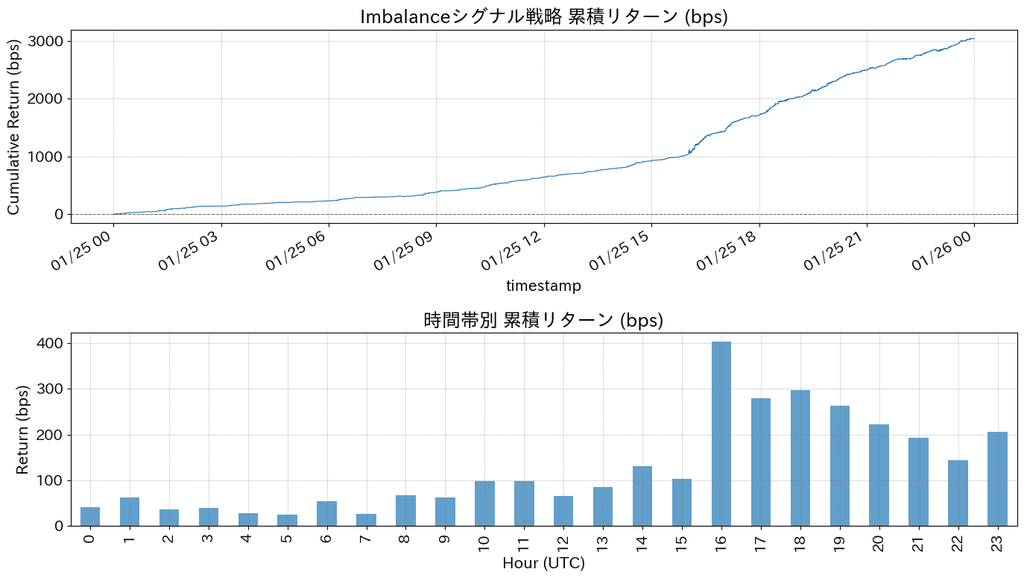

```python
# 累積リターンの可視化
fig, axes = plt.subplots(2, 1, figsize=(14, 8))

# 累積リターン
signal_df['cum_return_bps'].plot(ax=axes[0])
axes[0].set_title('Imbalanceシグナル戦略 累積リターン (bps)')
axes[0].set_ylabel('Cumulative Return (bps)')
axes[0].axhline(y=0, color='black', linestyle='--', alpha=0.5)

# 時間帯別のパフォーマンス
signal_df['hour'] = signal_df.index.hour
hourly_return = signal_df.groupby('hour')['strategy_return_bps'].sum()
hourly_return.plot(kind='bar', ax=axes[1], alpha=0.7)
axes[1].set_title('時間帯別 累積リターン (bps)')
axes[1].set_ylabel('Return (bps)')
axes[1].set_xlabel('Hour (UTC)')

plt.tight_layout()
plt.show()
```

## 7. 閾値付きシグナル戦略

Imbalanceが一定以上のときのみトレードする戦略。

```python
# 閾値を変えてパフォーマンスを確認
thresholds = [0.0, 0.1, 0.2, 0.3, 0.4, 0.5]
results = []

for thresh in thresholds:
    # シグナル生成（閾値以上のときのみ）
    signal = np.where(signal_df['imbalance'] > thresh, 1,
                      np.where(signal_df['imbalance'] < -thresh, -1, 0))

    # リターン計算
    strat_return = signal * signal_df['return_1s_bps'].shift(-1).values
    trade_count = np.sum(signal != 0)
    total_return = np.nansum(strat_return)
    avg_return = np.nanmean(strat_return[signal != 0]) if trade_count > 0 else 0

    results.append({
        'threshold': thresh,
        'trade_count': trade_count,
        'total_return_bps': total_return,
        'avg_return_bps': avg_return,
        'sharpe': np.nanmean(strat_return) / np.nanstd(strat_return) * np.sqrt(86400) if np.nanstd(strat_return) > 0 else 0
    })

results_df = pd.DataFrame(results)
print("閾値別パフォーマンス")
display(results_df.round(3))
```

```
閾値別パフォーマンス
```

|  | threshold | trade_count | total_return_bps | avg_return_bps | sharpe |
| --- | --- | --- | --- | --- | --- |
| 0 | 0.0 | 86229 | 3033.008 | 0.035 | 21.272 |
| 1 | 0.1 | 82356 | 3050.758 | 0.037 | 21.920 |
| 2 | 0.2 | 78534 | 3038.761 | 0.039 | 22.487 |
| 3 | 0.3 | 74590 | 3025.311 | 0.041 | 22.938 |
| 4 | 0.4 | 70632 | 2964.077 | 0.042 | 23.110 |
| 5 | 0.5 | 66202 | 2933.735 | 0.044 | 23.709 |

[figure not shown]

```python
# 可視化
fig, axes = plt.subplots(1, 2, figsize=(12, 5))

axes[0].bar(results_df['threshold'], results_df['total_return_bps'], alpha=0.7)
axes[0].set_xlabel('Threshold')
axes[0].set_ylabel('Total Return (bps)')
axes[0].set_title('閾値別 総リターン')

axes[1].bar(results_df['threshold'], results_df['avg_return_bps'], alpha=0.7, color='orange')
axes[1].set_xlabel('Threshold')
axes[1].set_ylabel('Avg Return per Trade (bps)')
axes[1].set_title('閾値別 取引あたり平均リターン')

plt.tight_layout()
plt.show()
```

### 次のステップ

1. 複数日のデータでの検証（ロバスト性確認）
2. 取引コスト（スプレッド、Taker Fee）を考慮したシミュレーション
3. より洗練されたシグナル（機械学習モデル等）の検討
4. MM戦略の具体的な設計（板への発注ロジック）